# Final Summary Paper

Arjun Bingly, Caroline Krall, Nayaeun Kwon, Tara Thomas

2022-12-13

# Midterm Recap

For the midterm, we combined datasets from IMDB, Rotten Tomatoes, and Box Office Mojo, to answer our SMART question: What factors affect box office performance sales in the US? We joined these three datasets through an inner join on movie title, where the year of release ranged from 1912 to 2022. We analyzed lifetime gross as our response variable, and for the final project, we decided to continue our analysis of our combined dataset with different SMART questions.

# Topic and Smart Questions

Topic: We are once again using the IMDb, Rotten Tomatoes, and lifetime gross datasets to perform analysis. Broadly, we want to understand which movies received high ratings, and how successfully we can predict the genre of the movie.We treated the analysis of genre are a yes or no problem. Instead of predicting which movie is which genre, we asked if a particular movie was a comedy or not. We used the IMDb genre variable as there were fewer issues with null values. SMART Questions: 1. What features affect IMDb Rating? 2. What features can be used to predict movie genre? 3. What features affect the Rotten Tomatoes freshness ratings?

# Data Cleaning

## Getting rid of the unnecessary columns and removing null values rows

```r
movie_red <-
  movie %>%
  select(X, movie_title, content_rating, genres.y, runtime, tomatometer_status, tomatometer_rating, tomatometer_count, lifetime_gross, startYear, averageRating, numVotes) %>%
  rename(genre = genres.y, imdbRating = averageRating) %>%
  na.omit()
```

### Genre Distribution

- Note that the genres are derived from the IMDB database, since it proved to be more diverse and accurate compared to the rotten tomatoes genres.

```
## # A tibble: 25 × 2
##    genre           n
##    <chr>       <int>
##  1 Drama        4297
##  2 Comedy       2865
##  3 Romance      1415
##  4 Crime        1297
##  5 Action       1279
##  6 Adventure    1019
##  7 Thriller      997
##  8 Documentary   744
##  9 Horror        617
## 10 Biography     607
## # … with 15 more rows
```

### Adding indicator variables for Genre

We created one-hot indicator variables for the top genres using the ‘ifelse’ and ‘str_detect’ functions.

### Making Indicators for Tomatometer Status

We created one-hot indicator variables for the Tomatometer Status using the ‘ifelse’ and ‘str_detect’ functions.

# SMART Question 1: What features affect IMDB rating?

### Overview: IMDB Rating Variable

#### Histogram of IMDB Rating Variable

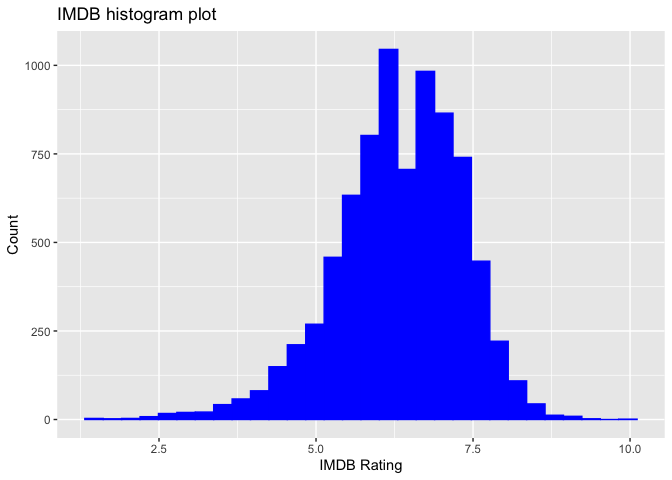

The IMDB Rating was very close to a normal distribution, therefore, no skew affected the model or analysis.

#### Summary of IMDB Rating Variable

Summary of IMDB Rating

| Min. | 1st Qu. | Median | Mean | 3rd Qu. | Max. |
| --- | --- | --- | --- | --- | --- |
| 1.5 | 5.8 | 6.4 | 6.32 | 7 | 10 |

### Feature Selection for IMDB Rating Prediction

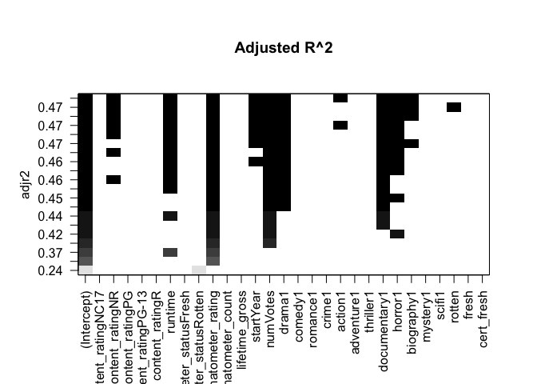

For the IMDB rating model, the model will be a linear regression since the response variable is continuous. With this model, the $R^2$ value quantifies the variance of our dependent variable, explained by our independent variables. We used adjusted $R^2$ because it takes into account the number of variables and penalizes a large number of variables, whereas $R^2$ favors models with an increasing number of variables. Due to having many independent variables, especially with each genre being considered as a separate variable, we decided to use the adjusted $R^2$ metric.

### Four Models based on feature selection & ANOVA

```
##
## Call:
## lm(formula = imdbRating ~ runtime + tomatometer_count + numVotes +
##     tomatometer_rating, data = movie_red)
##
## Residuals:
##    Min     1Q Median     3Q    Max
## -4.907 -0.351  0.075  0.442  3.255
##
## Coefficients:
##                     Estimate Std. Error t value Pr(>|t|)
## (Intercept)         4.55e+00   5.56e-02   81.89  < 2e-16 ***
## runtime             5.92e-03   5.34e-04   11.08  < 2e-16 ***
## tomatometer_count  -5.46e-04   1.30e-04   -4.21  2.6e-05 ***
## numVotes            1.41e-06   6.46e-08   21.90  < 2e-16 ***
## tomatometer_rating  1.97e-02   3.17e-04   62.16  < 2e-16 ***
## ---
## Signif. codes:  0 '***' 0.001 '**' 0.01 '*' 0.05 '.' 0.1 ' ' 1
##
## Residual standard error: 0.763 on 7956 degrees of freedom
## Multiple R-squared:  0.411,  Adjusted R-squared:  0.41
## F-statistic: 1.39e+03 on 4 and 7956 DF,  p-value: <2e-16
```

```
##
## Call:
## lm(formula = imdbRating ~ runtime + tomatometer_count + numVotes +
##     tomatometer_rating + drama + comedy + horror + biography,
##     data = movie_red)
##
## Residuals:
##    Min     1Q Median     3Q    Max
## -4.910 -0.336  0.075  0.429  3.185
##
## Coefficients:
##                     Estimate Std. Error t value Pr(>|t|)
## (Intercept)         4.89e+00   5.88e-02   83.16  < 2e-16 ***
## runtime             3.38e-03   5.48e-04    6.16  7.5e-10 ***
## tomatometer_count  -5.18e-04   1.27e-04   -4.07  4.7e-05 ***
## numVotes            1.53e-06   6.38e-08   24.05  < 2e-16 ***
## tomatometer_rating  1.86e-02   3.18e-04   58.39  < 2e-16 ***
## drama1              7.38e-02   1.80e-02    4.09  4.3e-05 ***
## comedy1            -1.24e-01   1.87e-02   -6.63  3.5e-11 ***
## horror1            -4.17e-01   3.27e-02  -12.77  < 2e-16 ***
## biography1          3.06e-01   3.25e-02    9.42  < 2e-16 ***
## ---
## Signif. codes:  0 '***' 0.001 '**' 0.01 '*' 0.05 '.' 0.1 ' ' 1
##
## Residual standard error: 0.747 on 7952 degrees of freedom
## Multiple R-squared:  0.436,  Adjusted R-squared:  0.436
## F-statistic:  769 on 8 and 7952 DF,  p-value: <2e-16
```

```
##
## Call:
## lm(formula = imdbRating ~ runtime + tomatometer_count + tomatometer_status +
##     numVotes + tomatometer_rating + content_rating, data = movie_red)
##
## Residuals:
##    Min     1Q Median     3Q    Max
## -4.835 -0.349  0.071  0.441  3.280
##
## Coefficients:
##                           Estimate Std. Error t value Pr(>|t|)
## (Intercept)               4.34e+00   9.46e-02   45.90  < 2e-16 ***
## runtime                   5.77e-03   5.41e-04   10.68  < 2e-16 ***
## tomatometer_count        -6.52e-04   1.41e-04   -4.63  3.7e-06 ***
## tomatometer_statusFresh  -1.89e-02   2.74e-02   -0.69     0.49
## tomatometer_statusRotten  1.60e-01   4.11e-02    3.90  9.6e-05 ***
## numVotes                  1.41e-06   6.48e-08   21.78  < 2e-16 ***
## tomatometer_rating        2.26e-02   6.49e-04   34.74  < 2e-16 ***
## content_ratingNC17        1.54e-01   1.89e-01    0.81     0.42
## content_ratingNR         -2.52e-02   6.37e-02   -0.40     0.69
## content_ratingPG         -1.57e-02   6.29e-02   -0.25     0.80
## content_ratingPG-13       3.38e-02   6.16e-02    0.55     0.58
## content_ratingR          -9.41e-03   6.01e-02   -0.16     0.88
## ---
## Signif. codes:  0 '***' 0.001 '**' 0.01 '*' 0.05 '.' 0.1 ' ' 1
##
## Residual standard error: 0.762 on 7949 degrees of freedom
## Multiple R-squared:  0.413,  Adjusted R-squared:  0.412
## F-statistic:  509 on 11 and 7949 DF,  p-value: <2e-16
```

```
##
## Call:
## lm(formula = imdbRating ~ runtime + tomatometer_count + tomatometer_status +
##     tomatometer_rating + +content_rating + numVotes + drama +
##     comedy + horror + biography, data = movie_red)
##
## Residuals:
##    Min     1Q Median     3Q    Max
## -4.859 -0.335  0.070  0.428  3.191
##
## Coefficients:
##                           Estimate Std. Error t value Pr(>|t|)
## (Intercept)               4.69e+00   9.58e-02   49.00  < 2e-16 ***
## runtime                   3.19e-03   5.53e-04    5.77  8.1e-09 ***
## tomatometer_count        -6.39e-04   1.38e-04   -4.64  3.6e-06 ***
## tomatometer_statusFresh  -2.04e-02   2.69e-02   -0.76  0.44769
## tomatometer_statusRotten  1.59e-01   4.02e-02    3.95  7.9e-05 ***
## tomatometer_rating        2.14e-02   6.39e-04   33.58  < 2e-16 ***
## content_ratingNC17        8.89e-02   1.85e-01    0.48  0.63075
## content_ratingNR         -5.95e-02   6.25e-02   -0.95  0.34062
## content_ratingPG         -2.71e-02   6.15e-02   -0.44  0.65971
## content_ratingPG-13       1.49e-02   6.04e-02    0.25  0.80525
## content_ratingR          -6.82e-03   5.92e-02   -0.12  0.90835
## numVotes                  1.53e-06   6.40e-08   23.88  < 2e-16 ***
## drama1                    6.88e-02   1.84e-02    3.74  0.00018 ***
## comedy1                  -1.27e-01   1.88e-02   -6.75  1.5e-11 ***
## horror1                  -4.22e-01   3.31e-02  -12.73  < 2e-16 ***
## biography1                3.07e-01   3.25e-02    9.45  < 2e-16 ***
## ---
## Signif. codes:  0 '***' 0.001 '**' 0.01 '*' 0.05 '.' 0.1 ' ' 1
##
## Residual standard error: 0.745 on 7945 degrees of freedom
## Multiple R-squared:  0.439,  Adjusted R-squared:  0.438
## F-statistic:  414 on 15 and 7945 DF,  p-value: <2e-16
```

```
## Analysis of Variance Table
##
## Model 1: imdbRating ~ runtime + tomatometer_count + numVotes + tomatometer_rating
## Model 2: imdbRating ~ runtime + tomatometer_count + numVotes + tomatometer_rating +
##     drama + comedy + horror + biography
## Model 3: imdbRating ~ runtime + tomatometer_count + tomatometer_status +
##     numVotes + tomatometer_rating + content_rating
## Model 4: imdbRating ~ runtime + tomatometer_count + tomatometer_status +
##     tomatometer_rating + +content_rating + numVotes + drama +
##     comedy + horror + biography
##   Res.Df  RSS Df Sum of Sq  F Pr(>F)
## 1   7956 4637
## 2   7952 4435  4       202 91 <2e-16 ***
## 3   7949 4617  3      -183
## 4   7945 4415  4       202 91 <2e-16 ***
## ---
## Signif. codes:  0 '***' 0.001 '**' 0.01 '*' 0.05 '.' 0.1 ' ' 1
```

Four models were fit based on the adjusted $R^2$ value. The first model included the quantitative variables, the second included the significant genres, the third included the two categorical variables without genre, and the fourth included the significant quantitative, qualitative, and genre variables.

# SMART Question 2: Which features can be used to predict movie genre?

After counting genre, we decided to select top 3 genres, drama, comedy, and romance to predict the most affected feature to the genre.

## Skewness of genres

We are predicting the variables with an indicator variable, which is whether the movie genre is ‘drama’ or not. In addition, since from the count table on the top, we already selected the top 3 genres that have about 50% proportion from total genre counts.

Firstly, let’s look at drama genre.

## Drama Genre

Variables considered for feature selection:

```
## [1] "content_rating"     "runtime"            "tomatometer_rating"
## [4] "lifetime_gross"     "year"               "imdbRating"
## [7] "numVotes"
```

The best model after exhaustive search:

```
##   content_rating runtime tomatometer_rating lifetime_gross  year imdbRating
## 1           TRUE    TRUE               TRUE           TRUE FALSE       TRUE
## 2           TRUE    TRUE               TRUE           TRUE  TRUE       TRUE
## 3           TRUE    TRUE               TRUE           TRUE FALSE       TRUE
## 4           TRUE    TRUE               TRUE           TRUE  TRUE       TRUE
## 5           TRUE    TRUE              FALSE           TRUE FALSE       TRUE
##   numVotes Criterion
## 1     TRUE      9840
## 2     TRUE      9842
## 3    FALSE      9852
## 4    FALSE      9853
## 5     TRUE      9862
```

```
##
## Call:
## glm(formula = y ~ ., family = family, data = Xi, weights = weights)
##
## Deviance Residuals:
##    Min      1Q  Median      3Q     Max
## -2.857  -1.090   0.611   1.008   3.646
##
## Coefficients:
##                      Estimate Std. Error z value Pr(>|z|)
## (Intercept)         -5.69e+00   2.97e-01  -19.16  < 2e-16 ***
## content_ratingNC17   1.03e+00   5.47e-01    1.88  0.06007 .
## content_ratingNR     1.42e-01   1.99e-01    0.72  0.47403
## content_ratingPG     3.22e-01   1.97e-01    1.63  0.10210
## content_ratingPG-13  7.26e-01   1.93e-01    3.76  0.00017 ***
## content_ratingR      9.57e-01   1.90e-01    5.03  5.0e-07 ***
## runtime              3.68e-02   1.83e-03   20.05  < 2e-16 ***
## tomatometer_rating   5.49e-03   1.12e-03    4.91  9.3e-07 ***
## lifetime_gross      -9.87e-09   7.51e-10  -13.15  < 2e-16 ***
## imdbRating           2.18e-01   3.21e-02    6.80  1.0e-11 ***
## numVotes            -8.82e-07   2.29e-07   -3.85  0.00012 ***
## ---
## Signif. codes:  0 '***' 0.001 '**' 0.01 '*' 0.05 '.' 0.1 ' ' 1
##
## (Dispersion parameter for binomial family taken to be 1)
##
##     Null deviance: 10986  on 7960  degrees of freedom
## Residual deviance:  9820  on 7950  degrees of freedom
## AIC: 9842
##
## Number of Fisher Scoring iterations: 4
```

According to feature selection through AIC, the best model has AIC 9840 with all variables, `content_rating`, `runtime`, `tomatometer_rating`, `lifetime_gross`, `imbdRating`, and `numVotes` except `year`.

```
##
##  Hosmer and Lemeshow goodness of fit (GOF) test
##
## data:  movieclean$y, fitted(dramaglm)
## X-squared = 7961, df = 8, p-value <2e-16
```

## Comedy Genre

The best model after exhaustive search:

```
##   content_rating runtime tomatometer_rating lifetime_gross  year imdbRating
## 1           TRUE    TRUE               TRUE           TRUE  TRUE       TRUE
## 2           TRUE    TRUE               TRUE           TRUE  TRUE       TRUE
## 3           TRUE    TRUE              FALSE           TRUE  TRUE       TRUE
## 4           TRUE    TRUE              FALSE           TRUE  TRUE       TRUE
## 5           TRUE    TRUE               TRUE           TRUE FALSE       TRUE
##   numVotes Criterion
## 1    FALSE      9643
## 2     TRUE      9644
## 3    FALSE      9659
## 4     TRUE      9661
## 5    FALSE      9670
```

```
##
## Call:
## glm(formula = y ~ ., family = family, data = Xi, weights = weights)
##
## Deviance Residuals:
##    Min      1Q  Median      3Q     Max
## -1.820  -0.936  -0.692   1.192   2.876
##
## Coefficients:
##                      Estimate Std. Error z value Pr(>|z|)
## (Intercept)         -1.08e+01   2.82e+00   -3.83  0.00013 ***
## content_ratingNC17  -7.87e-01   5.59e-01   -1.41  0.15962
## content_ratingNR    -1.25e+00   1.83e-01   -6.86  7.0e-12 ***
## content_ratingPG     1.03e-01   1.74e-01    0.59  0.55196
## content_ratingPG-13 -3.05e-01   1.71e-01   -1.79  0.07385 .
## content_ratingR     -5.74e-01   1.68e-01   -3.41  0.00064 ***
## runtime             -2.76e-02   1.84e-03  -14.98  < 2e-16 ***
## tomatometer_rating  -4.85e-03   1.13e-03   -4.29  1.8e-05 ***
## lifetime_gross       2.97e-09   4.79e-10    6.19  6.0e-10 ***
## year                 7.45e-03   1.41e-03    5.29  1.2e-07 ***
## imdbRating          -1.90e-01   3.13e-02   -6.07  1.3e-09 ***
## ---
## Signif. codes:  0 '***' 0.001 '**' 0.01 '*' 0.05 '.' 0.1 ' ' 1
##
## (Dispersion parameter for binomial family taken to be 1)
##
##     Null deviance: 10402.6  on 7960  degrees of freedom
## Residual deviance:  9622.8  on 7950  degrees of freedom
## AIC: 9645
##
## Number of Fisher Scoring iterations: 4
```

According to the future selection with AIC, the best model has AIC 9643 with all variables except `numVotes`.

```
##
##  Hosmer and Lemeshow goodness of fit (GOF) test
##
## data:  movieclean$y, fitted(comedyglm)
## X-squared = 7961, df = 8, p-value <2e-16
```

## Romance Genre

The best model after exhaustive search:

```
##   content_rating runtime tomatometer_rating lifetime_gross year imdbRating
## 1           TRUE    TRUE               TRUE           TRUE TRUE       TRUE
## 2           TRUE    TRUE               TRUE           TRUE TRUE      FALSE
## 3           TRUE    TRUE              FALSE           TRUE TRUE      FALSE
## 4           TRUE    TRUE              FALSE           TRUE TRUE       TRUE
## 5           TRUE   FALSE               TRUE           TRUE TRUE       TRUE
##   numVotes Criterion
## 1     TRUE      7282
## 2     TRUE      7283
## 3     TRUE      7288
## 4     TRUE      7290
## 5     TRUE      7290
```

```
##
## Call:
## glm(formula = y ~ ., family = family, data = Xi, weights = weights)
##
## Deviance Residuals:
##    Min      1Q  Median      3Q     Max
## -1.115  -0.658  -0.581  -0.477   2.963
##
## Coefficients:
##                      Estimate Std. Error z value Pr(>|z|)
## (Intercept)          8.65e+00   3.15e+00    2.74  0.00612 **
## content_ratingNC17   1.15e+00   6.43e-01    1.79  0.07392 .
## content_ratingNR     6.36e-01   3.18e-01    2.00  0.04504 *
## content_ratingPG     6.48e-01   3.14e-01    2.06  0.03899 *
## content_ratingPG-13  1.35e+00   3.07e-01    4.41  1.1e-05 ***
## content_ratingR      8.84e-01   3.06e-01    2.89  0.00386 **
## runtime              6.19e-03   1.86e-03    3.33  0.00088 ***
## tomatometer_rating  -4.31e-03   1.35e-03   -3.18  0.00145 **
## lifetime_gross      -3.42e-09   9.79e-10   -3.50  0.00047 ***
## year                -5.92e-03   1.56e-03   -3.80  0.00015 ***
## imdbRating           6.87e-02   3.89e-02    1.77  0.07712 .
## numVotes            -1.28e-06   4.08e-07   -3.13  0.00173 **
## ---
## Signif. codes:  0 '***' 0.001 '**' 0.01 '*' 0.05 '.' 0.1 ' ' 1
##
## (Dispersion parameter for binomial family taken to be 1)
##
##     Null deviance: 7450.7  on 7960  degrees of freedom
## Residual deviance: 7259.5  on 7949  degrees of freedom
## AIC: 7284
##
## Number of Fisher Scoring iterations: 5
```

According to the result of feature selection with AIC, the best model has AIC 7282 with all variables, `content_rating`, `runtime`, `tomatometer_rating`, `lifetime_gross`, `year`, `imbdRating`, and `numVotes`.

```
##
##  Hosmer and Lemeshow goodness of fit (GOF) test
##
## data:  movieclean$y, fitted(romanceglm)
## X-squared = 7961, df = 8, p-value <2e-16
```

Displaying feature selection with AIC, we conclude that `content_rating`, `runtime`, `tomatometer_rating`, `lifetime_gross`, `imdbRating` are decisive features to all genres which are drama, comedy, and romance. Specially, `numVotes` variable affect only drama and romance genre and `year` variables affect only comedy and romance genre.

# SMART Question 3: What features affect the Rotten Tomato freshness ratings?

## Adding indicator variables for each Genre

It can be noted that only 109 movies are not classified in the top 12 genres, which is about 1.369% of total movies.

## What is tomatometer status?

There are 3 Tomatometer statuses - Rotten, Fresh and Certified Fresh.

- A movie is considered ‘Rotten’ when less than 60% of the reviews of the movie are positive.
- A movie is considered ‘Fresh’ when at least 60% of the reviews of the movie are positive.
- ‘Certified Fresh’ status is a special distinction awarded to the best-reviewed movies. In order to qualify, movies or TV shows must meet the following requirements:
  - A consistent Tomatometer score of 75% or higher.
  - At least five reviews from Top Critics.
  - Films in wide release must have a minimum of 80 reviews. This also applies for films going from limited to wide release.
  - Films in limited release must have a minimum of 40 reviews.
  - Only individual seasons of a TV show are eligible, and each must have a minimum of 20 reviews.

## Tomatometer Status Distribution

Having a look at the count of each category.

```
## # A tibble: 3 × 2
##   tomatometer_status     n
##   <chr>              <int>
## 1 Rotten              4026
## 2 Fresh               2081
## 3 Certified-Fresh     1854
```

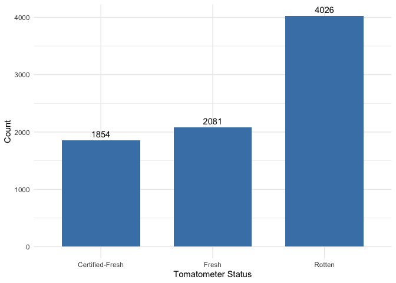

## Is our data unbalanced?

From the first look at the bar chart, one might think that the data might be slightly unbalanced but since we are using logistic regression. We are predicting a binary outcome, which would be is the movie ‘Rotten’ or not. This would imply that we are consolidating the ‘Fresh’ and ‘Certified-Fresh’ groups, this makes the data quite balanced. Moreover, it is worthy to note that ‘Certified-Fresh’ is a special distinction given to ‘Fresh’ movies, hence this would not throw our model off.

## Logistic regression model.

The aim is to build a model to predict if a movie is ‘Rotten’ or not. The predictors considered IMDB ratings and vote count, year of release, runtime, content rating, lifetime gross and genre (as shown above)

Removing variables not considered in the model. This is how the dataframe looks like:

```
## 'data.frame':    7961 obs. of  20 variables:
##  $ content_rating: chr  "R" "PG-13" "R" "R" ...
##  $ runtime       : int  90 100 110 143 124 87 86 90 103 77 ...
##  $ lifetime_gross: int  4033574 25473352 32078318 2484186 49981 929233 849915 132261 44544 1008404 ...
##  $ year          : int  2010 2001 1949 1920 1929 1994 1944 2001 1996 1991 ...
##  $ imbdRating    : num  6.6 5.1 6.8 3.6 7 5.3 7.1 2.9 7 5.6 ...
##  $ numVotes      : int  11359 199 960 32 89 46 1239 101 655 3884 ...
##  $ drama         : Factor w/ 2 levels "0","1": 2 2 2 1 2 2 2 1 1 2 ...
##  $ comedy        : Factor w/ 2 levels "0","1": 2 1 1 1 1 1 1 1 2 1 ...
##  $ romance       : Factor w/ 2 levels "0","1": 1 1 2 1 1 1 1 2 1 1 ...
##  $ crime         : Factor w/ 2 levels "0","1": 1 2 1 1 1 2 1 1 1 1 ...
##  $ action        : Factor w/ 2 levels "0","1": 1 1 1 2 1 1 1 1 1 1 ...
##  $ adventure     : Factor w/ 2 levels "0","1": 1 1 1 2 1 1 2 1 1 1 ...
##  $ thriller      : Factor w/ 2 levels "0","1": 1 1 1 1 1 1 1 2 1 1 ...
##  $ documentary   : Factor w/ 2 levels "0","1": 1 1 1 1 1 1 1 1 1 1 ...
##  $ horror        : Factor w/ 2 levels "0","1": 1 1 1 1 1 1 1 1 1 1 ...
##  $ biography     : Factor w/ 2 levels "0","1": 1 1 1 1 1 1 2 1 1 1 ...
##  $ mystery       : Factor w/ 2 levels "0","1": 1 2 1 1 1 1 1 1 1 1 ...
##  $ fantasy       : Factor w/ 2 levels "0","1": 1 1 1 1 1 1 1 1 1 1 ...
##  $ scifi         : Factor w/ 2 levels "0","1": 1 1 1 1 1 1 1 1 1 1 ...
##  $ rotten        : Factor w/ 2 levels "0","1": 1 1 1 2 2 1 1 1 1 2 ...
##  - attr(*, "na.action")= 'omit' Named int [1:26] 221 271 348 627 654 1330 1469 1594 1705 1788 ...
##   ..- attr(*, "names")= chr [1:26] "221" "271" "348" "627" ...
```

### Exhaustive search

- Exhaustive search with all the 19 variables, takes a long time (~10hrs). This is not surprising, since the total number of combinations possible (without interactions) is 524288 models. (Calculated below.)

```
## Initialization...
## TASK: Diagnostic of candidate set.
## Sample size: 7961
## 13 factor(s).
## 6 covariate(s).
## 0 f exclusion(s).
## 0 c exclusion(s).
## 0 f:f exclusion(s).
## 0 c:c exclusion(s).
## 0 f:c exclusion(s).
## Size constraints: min =  0 max = -1
## Complexity constraints: min =  0 max = -1
## Your candidate set contains 524288 models.
```

- Note that we had run this 10 hour long exhaustive search and results are the same as that run below.
- We have reduced the total number of variables to 15, eliminating the genres with least count (these eliminated variables played almost no role in the results we got from the full search).
- Eliminating these genres would mean that we now have, 131 movies are not classified in genres considered, which is about 1.646% of total movies, which is very less and should not have a huge impact on the model.

```
## 'data.frame':    7961 obs. of  16 variables:
##  $ content_rating: chr  "R" "PG-13" "R" "R" ...
##  $ runtime       : int  90 100 110 143 124 87 86 90 103 77 ...
##  $ lifetime_gross: int  4033574 25473352 32078318 2484186 49981 929233 849915 132261 44544 1008404 ...
##  $ year          : int  2010 2001 1949 1920 1929 1994 1944 2001 1996 1991 ...
##  $ imbdRating    : num  6.6 5.1 6.8 3.6 7 5.3 7.1 2.9 7 5.6 ...
##  $ numVotes      : int  11359 199 960 32 89 46 1239 101 655 3884 ...
##  $ drama         : Factor w/ 2 levels "0","1": 2 2 2 1 2 2 2 1 1 2 ...
##  $ comedy        : Factor w/ 2 levels "0","1": 2 1 1 1 1 1 1 1 2 1 ...
##  $ romance       : Factor w/ 2 levels "0","1": 1 1 2 1 1 1 1 2 1 1 ...
##  $ crime         : Factor w/ 2 levels "0","1": 1 2 1 1 1 2 1 1 1 1 ...
##  $ action        : Factor w/ 2 levels "0","1": 1 1 1 2 1 1 1 1 1 1 ...
##  $ adventure     : Factor w/ 2 levels "0","1": 1 1 1 2 1 1 2 1 1 1 ...
##  $ thriller      : Factor w/ 2 levels "0","1": 1 1 1 1 1 1 1 2 1 1 ...
##  $ documentary   : Factor w/ 2 levels "0","1": 1 1 1 1 1 1 1 1 1 1 ...
##  $ horror        : Factor w/ 2 levels "0","1": 1 1 1 1 1 1 1 1 1 1 ...
##  $ rotten        : Factor w/ 2 levels "0","1": 1 1 1 2 2 1 1 1 1 2 ...
##  - attr(*, "na.action")= 'omit' Named int [1:26] 221 271 348 627 654 1330 1469 1594 1705 1788 ...
##   ..- attr(*, "names")= chr [1:26] "221" "271" "348" "627" ...
```

First lets look at how many combinations are possible.

```
## Initialization...
## TASK: Diagnostic of candidate set.
## Sample size: 7961
## 9 factor(s).
## 6 covariate(s).
## 0 f exclusion(s).
## 0 c exclusion(s).
## 0 f:f exclusion(s).
## 0 c:c exclusion(s).
## 0 f:c exclusion(s).
## Size constraints: min =  0 max = -1
## Complexity constraints: min =  0 max = -1
## Your candidate set contains 32768 models.
```

We can see that just reducing the the number of variables from 19 to 15 we have reduced the number of combinations from 524288 to 32768, which is about a 93% reduction!!

### Plots

Plot of the scoring criteria, BIC arranged from best model to worst (128 models). The red line shows models that are less that 2 BIC units away from the best model.

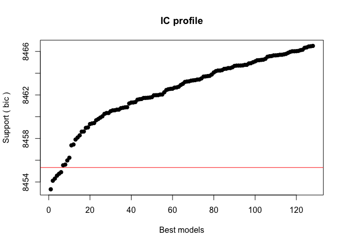

Plot of relative importance of variables.

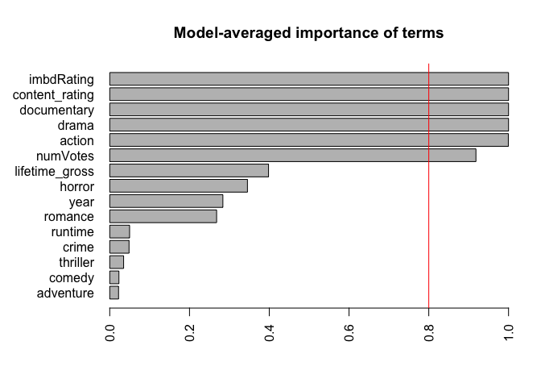

Model formulas of 5 best models:

```
## [[1]]
## rotten ~ 1 + drama + action + documentary + content_rating +
##     imbdRating + numVotes
## <environment: 0x7fde28936978>
##
## [[2]]
## rotten ~ 1 + drama + action + documentary + content_rating +
##     lifetime_gross + imbdRating + numVotes
## <environment: 0x7fde28936978>
##
## [[3]]
## rotten ~ 1 + drama + action + documentary + content_rating +
##     year + imbdRating + numVotes
## <environment: 0x7fde28936978>
##
## [[4]]
## rotten ~ 1 + drama + action + documentary + horror + content_rating +
##     lifetime_gross + imbdRating + numVotes
## <environment: 0x7fde28936978>
##
## [[5]]
## rotten ~ 1 + drama + action + documentary + horror + content_rating +
##     imbdRating + numVotes
## <environment: 0x7fde28936978>
```

## Model Testing

We will be testing the model by using a 10 times repeated 5 fold Cross Validation. We will be looking at both the classification accuracy and Cohen’s Kappa.

```
##   parameter Accuracy Kappa AccuracySD KappaSD
## 1      none    0.754 0.508    0.01007  0.0201
## 2      none    0.755 0.509    0.01089  0.0218
## 3      none    0.754 0.508    0.01083  0.0217
## 4      none    0.754 0.508    0.00818  0.0164
## 5      none    0.754 0.507    0.01041  0.0209
```

Let us now look at the AUC of our best model.

- We could not figure out how to plot AUC with repeated CV, so we are doing it with a train-test split

[output not shown]

Exponential of coefficients in Logit Reg

|  | x |
| --- | --- |
| (Intercept) | 0.539 |
| content_ratingNC17 | 1.566 |
| content_ratingNR | 0.484 |
| content_ratingPG | 1.560 |
| `content_ratingPG-13` | 2.455 |
| content_ratingR | 1.450 |
| year | 1.004 |
| imbdRating | 0.299 |
| numVotes | 1.000 |
| drama1 | 0.694 |
| action1 | 1.498 |
| documentary1 | 0.365 |

CIs using standard errors

|  | 2.5 % | 97.5 % |
| --- | --- | --- |
| (Intercept) | -6.3954 | 5.158 |
| content_ratingNC17 | -0.6412 | 1.538 |
| content_ratingNR | -1.1452 | -0.306 |
| content_ratingPG | 0.0448 | 0.844 |
| `content_ratingPG-13` | 0.5064 | 1.290 |
| content_ratingR | -0.0134 | 0.756 |
| year | 0.0013 | 0.007 |
| imbdRating | -1.2888 | -1.126 |
| numVotes | 0.0000 | 0.000 |
| drama1 | -0.4862 | -0.246 |
| action1 | 0.2446 | 0.563 |
| documentary1 | -1.2750 | -0.743 |

Confusion matrix from Logit Model

|  | Predicted 0 | Predicted 1 | Total |
| --- | --- | --- | --- |
| Actual 0 | 2924 | 1011 | 3935 |
| Actual 1 | 933 | 3093 | 4026 |
| Total | 3857 | 4104 | 7961 |

```
## 'log Lik.' 0.244 (df=12)
```

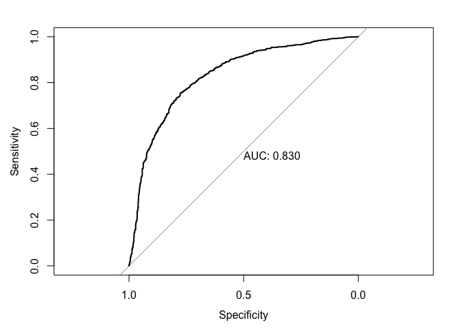

# Conclusion

SMART Questions:

While we had relative success with our linear model to predict IMDb rating and using logistic regression to predict tomatometer status, the models for predicting the various genres were not fitted super well.

# Limitations and Extensions

Because both the rotten tomatoes and IMDb datasets have a genre variable, we as a group had to guess which one was better. Since the IMDb dataset overall is more complete and cleaner, we chose to use that one. They do generate slightly different counts, however both of the top two genres are the same across datasets. The rotten tomatoes data gives action as the third most common movie type. We have no way to analyze which of these two variables actually classifies the movies more accurately, especially given that each film can have one to three genres listed. We also didn’t account for the difference between a movie which lists the first genre as drama versus those which listed it second of third.

In the future, classifying genre could be treated as a classification problem, which may yield more significant results. For instance, we could use multinomial logistic regression, a neural network, or a random forest to classify all the genres, rather than analyzing each separately. Another investigation we would consider is a deeper look into seasonal trends and overarching trends in time for box office and IMDb rating.

# Bibliography

Box Office Mojo. Retrieved October 2, 2022, from https://www.boxofficemojo.com IMDB. Retrieved October 2, 2022, from https://www.imdb.com/interfaces/ Rotten Tomatoes. Retrieved October 2, 2022, from https://www.kaggle.com/datasets/stefanoleone992/rotten-tomatoes-movies-and-critic-reviews-dataset